# Question Phase

Next I'd like to check the survival rate on children, and since there isn't a column states whether someone is children(age under 18) or not, we need a function to tell if a record was a child or not. And we need a new column to store the information

```python
def Child_Classifier(age):
    # return Children if the person is a child, and Adult otherwise
    if age < 18:
        return 'Children'
    else:
        return 'Adult'
```

```python
# Create a new column to store the info
df['Child'] = df['Age'].apply(Child_Classifier)
df.head()
```

|  | PassengerId | Survived | Pclass | Name | Sex | Age | SibSp | Parch | Ticket | Fare | Cabin | Embarked | Child |
| --- | --- | --- | --- | --- | --- | --- | --- | --- | --- | --- | --- | --- | --- |
| 0 | 1 | 0 | 3 | Braund, Mr. Owen Harris | male | 22.0 | 1 | 0 | A/5 21171 | 7.2500 | NaN | S | Adult |
| 1 | 2 | 1 | 1 | Cumings, Mrs. John Bradley (Florence Briggs Th... | female | 38.0 | 1 | 0 | PC 17599 | 71.2833 | C85 | C | Adult |
| 2 | 3 | 1 | 3 | Heikkinen, Miss. Laina | female | 26.0 | 0 | 0 | STON/O2. 3101282 | 7.9250 | NaN | S | Adult |
| 3 | 4 | 1 | 1 | Futrelle, Mrs. Jacques Heath (Lily May Peel) | female | 35.0 | 1 | 0 | 113803 | 53.1000 | C123 | S | Adult |
| 4 | 5 | 0 | 3 | Allen, Mr. William Henry | male | 35.0 | 0 | 0 | 373450 | 8.0500 | NaN | S | Adult |

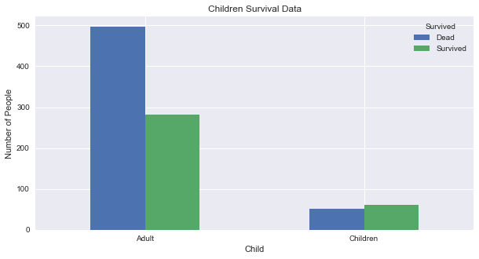

```python
# Plot the survival data against selected group to break down the data
Children_Sur = pd.crosstab(df.Child, df.Survived)
Children_Sur.rename(columns={0:'Dead',1:'Survived'},inplace=True)
Children_Sur.plot.bar(figsize=(10,5), rot=0).set_ylabel("Number of People")
plt.title('Children Survival Data')
```

The casualty rate for Adult is much higher than Children group

[figure not shown]

```python
# Now we can check the survival rate over class in terms of whether someone is child, this time I chose to use
# another way to plot the data for simplicity
sns.factorplot('Pclass',data=df[df.Survived==0],hue='Child',kind='count')
```

[output not shown]

```python
def Alone_Passenger(family):
    no_of_sipsp, no_of_parch = family
    no_of_relatives = no_of_sipsp + no_of_parch
    # Return 'Alone' if alone, 'Have relatives' otherwise
    if no_of_relatives == 0:
        return 'Alone'
    else:
        return 'Have relatives'
```

```python
# Create a new column to store the alone info, and this time we need to specify axis for apply since there're
# 2 columns involved
df['Alone'] = df[['SibSp','Parch']].apply(Alone_Passenger, axis = 1)
df.head()
```

|  | PassengerId | Survived | Pclass | Name | Sex | Age | SibSp | Parch | Ticket | Fare | Cabin | Embarked | Child | Alone |
| --- | --- | --- | --- | --- | --- | --- | --- | --- | --- | --- | --- | --- | --- | --- |
| 0 | 1 | 0 | 3 | Braund, Mr. Owen Harris | male | 22.0 | 1 | 0 | A/5 21171 | 7.2500 | NaN | S | Adult | Have relatives |
| 1 | 2 | 1 | 1 | Cumings, Mrs. John Bradley (Florence Briggs Th... | female | 38.0 | 1 | 0 | PC 17599 | 71.2833 | C85 | C | Adult | Have relatives |
| 2 | 3 | 1 | 3 | Heikkinen, Miss. Laina | female | 26.0 | 0 | 0 | STON/O2. 3101282 | 7.9250 | NaN | S | Adult | Alone |
| 3 | 4 | 1 | 1 | Futrelle, Mrs. Jacques Heath (Lily May Peel) | female | 35.0 | 1 | 0 | 113803 | 53.1000 | C123 | S | Adult | Have relatives |
| 4 | 5 | 0 | 3 | Allen, Mr. William Henry | male | 35.0 | 0 | 0 | 373450 | 8.0500 | NaN | S | Adult | Alone |

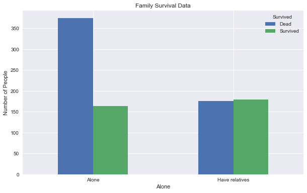

```python
Alone_Sur = pd.crosstab(df.Alone, df.Survived)
Alone_Sur.rename(columns={0:'Dead',1:'Survived'},inplace=True)
Alone_Sur.plot.bar(figsize=(10,6),rot=0).set_ylabel("Number of People")
plt.title('Family Survival Data')
```

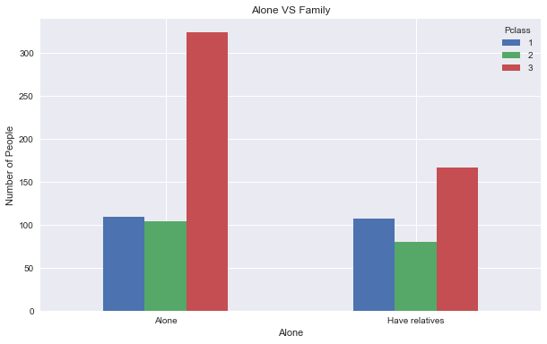

```python
Class_Alone_Sur = pd.crosstab(df.Alone, df.Pclass)
#Children_Sur.rename(columns={0:'Dead',1:'Survived'},inplace=True)
Class_Alone_Sur.plot.bar(figsize=(10,6),rot=0).set_ylabel("Number of People")
plt.title('Alone VS Family')
```

We can know from above chart that a lot more alone passengers (without any relative on board the ship) lost their lives than those with relative(s), whilst this difference is not that big for survivors.

Code Reference for the project:

1. http://pandas.pydata.org/pandas-docs/stable/10min.html#getting
2. https://stackoverflow.com/questions/15315452/selecting-with-complex-criteria-from-pandas-dataframe
3. http://www.cnblogs.com/jasonfreak/p/5441512.html
4. http://pandas.pydata.org/pandas-docs/stable/missing_data.html
5. http://pandas.pydata.org/pandas-docs/stable/visualization.html

# Conclusion

As we can see from above analysis, more women than men survived in this tragedy. And people who age at around 20 and 30 have a lower survival rate than other age groups.

Children in class 3 also have a higher casualty than those in class 1 and 2, and the same for those people who traveled alone (versus those men with relative(s). The analysis reveals that most of them are in class 3， it might because young immigrants often travel alone.

Due to some demography info not provided in this dataset, some further analysis are yet to be performed. My analysis only look into some simple statistic into the data. I would like to use logistic regression to build a model and see what features affect the survival rate and try to predict what kind of passenger is more likely to survive.